# Exploratory Data Analysis on Vehicle Collisions in NY

YC

*The vehicle collision data was collected by the NYPD and published by NYC OpenData*

```r
packages.required = c("plotly","highcharter","lubridate","ggthemes","tidyr","viridis","dplyr","tweenr")
install.packages(packages.required)
lapply(packages.required, library, character.only = TRUE)
```

Load the data, and examine the structure

```
## 'data.frame':    477732 obs. of  29 variables:
##  $ UNIQUE.KEY         : int  3146911 3146180 3146384 3146013 3146120 3145968 3146102 3146344 3145900 3145960 ...
##  $ DATE               : chr  "01/01/2015" "01/01/2015" "01/01/2015" "01/01/2015" ...
##  $ TIME               : chr  "0:20" "0:20" "0:21" "0:30" ...
##  $ BOROUGH            : chr  "QUEENS" "" "BROOKLYN" "BROOKLYN" ...
##  $ ZIP.CODE           : int  11358 NA 11205 11213 NA 11203 11105 11203 10024 11223 ...
##  $ LATITUDE           : num  40.8 40.8 40.7 40.7 NA ...
##  $ LONGITUDE          : num  -73.8 -73.9 -74 -73.9 NA ...
##  $ LOCATION           : chr  "(40.7518471, -73.787862)" "(40.7712888, -73.9466928)" "(40.6894449, -73.9551212)" "(40.6738445, -73.9250801)" ...
##  $ ON.STREET.NAME     : chr  "47 AVENUE" "" "BEDFORD AVENUE" "BUFFALO AVENUE" ...
##  $ CROSS.STREET.NAME  : chr  "193 STREET" "" "LAFAYETTE AVENUE" "SAINT MARKS AVENUE" ...
##  $ OFF.STREET.NAME    : chr  "" "" "" "" ...
##  $ PERSONS.INJURED    : int  0 1 0 0 0 2 0 0 1 0 ...
##  $ PERSONS.KILLED     : int  0 0 0 0 0 0 0 0 0 0 ...
##  $ PEDESTRIANS.INJURED: int  0 0 0 0 0 0 0 0 1 0 ...
##  $ PEDESTRIANS.KILLED : int  0 0 0 0 0 0 0 0 0 0 ...
##  $ CYCLISTS.INJURED   : int  0 0 0 0 0 0 0 0 0 0 ...
##  $ CYCLISTS.KILLED    : int  0 0 0 0 0 0 0 0 0 0 ...
##  $ MOTORISTS.INJURED  : int  0 1 0 0 0 2 0 0 0 0 ...
##  $ MOTORISTS.KILLED   : int  0 0 0 0 0 0 0 0 0 0 ...
##  $ VEHICLE.1.TYPE     : chr  "SPORT UTILITY/STATION WAGON" "PASSENGER VEHICLE" "PASSENGER VEHICLE" "BUS" ...
##  $ VEHICLE.2.TYPE     : chr  "" "" "UNKNOWN" "PASSENGER VEHICLE" ...
##  $ VEHICLE.3.TYPE     : chr  "" "" "" "" ...
##  $ VEHICLE.4.TYPE     : chr  "" "" "" "" ...
##  $ VEHICLE.5.TYPE     : chr  "" "" "" "" ...
##  $ VEHICLE.1.FACTOR   : chr  "TRAFFIC CONTROL DISREGARDED" "ANIMALS ACTION" "FATIGUED/DROWSY" "LOST CONSCIOUSNESS" ...
##  $ VEHICLE.2.FACTOR   : chr  "" "" "UNSPECIFIED" "" ...
##  $ VEHICLE.3.FACTOR   : chr  "" "" "" "" ...
##  $ VEHICLE.4.FACTOR   : chr  "" "" "" "" ...
##  $ VEHICLE.5.FACTOR   : chr  "" "" "" "" ...
```

#### Number of Accidents

**Number of Accidents Per Person**

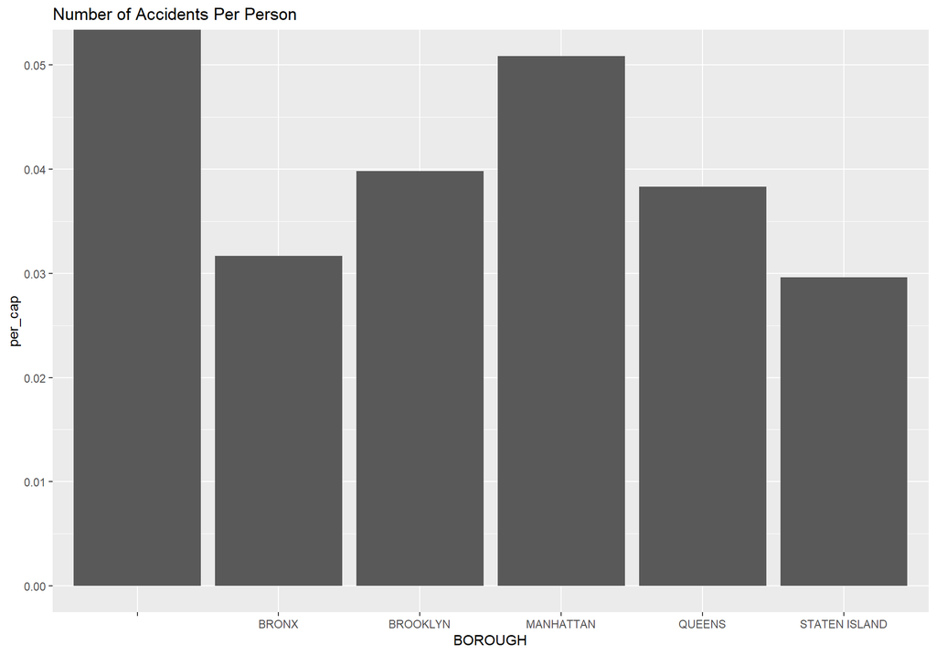

```r
#temp_1<- col %>% group_by(BOROUGH) %>% summarise(n=n())
temp_1<- col %>% group_by(BOROUGH) %>% tally()
temp_1$pop <- rep(0,dim(temp_1)[1])
temp_1$pop <- ifelse(temp_1$BOROUGH=="MANHATTAN",1644158,temp_1$pop)
temp_1$pop <- ifelse(temp_1$BOROUGH=="BRONX",1455444,temp_1$pop)
temp_1$pop <- ifelse(temp_1$BOROUGH=="QUEENS",2339150,temp_1$pop)
temp_1$pop <- ifelse(temp_1$BOROUGH=="STATEN ISLAND",474558,temp_1$pop)
temp_1$pop <- ifelse(temp_1$BOROUGH=="BROOKLYN",2636735,temp_1$pop)
temp_1$per_cap <- temp_1$n/temp_1$pop
temp_1 %>% ggplot(aes(x=BOROUGH,y=per_cap))+geom_bar(stat="identity")+ggtitle("Number of Accidents Per Person")
```

**Number of Collisions by Day and Hour and Area**

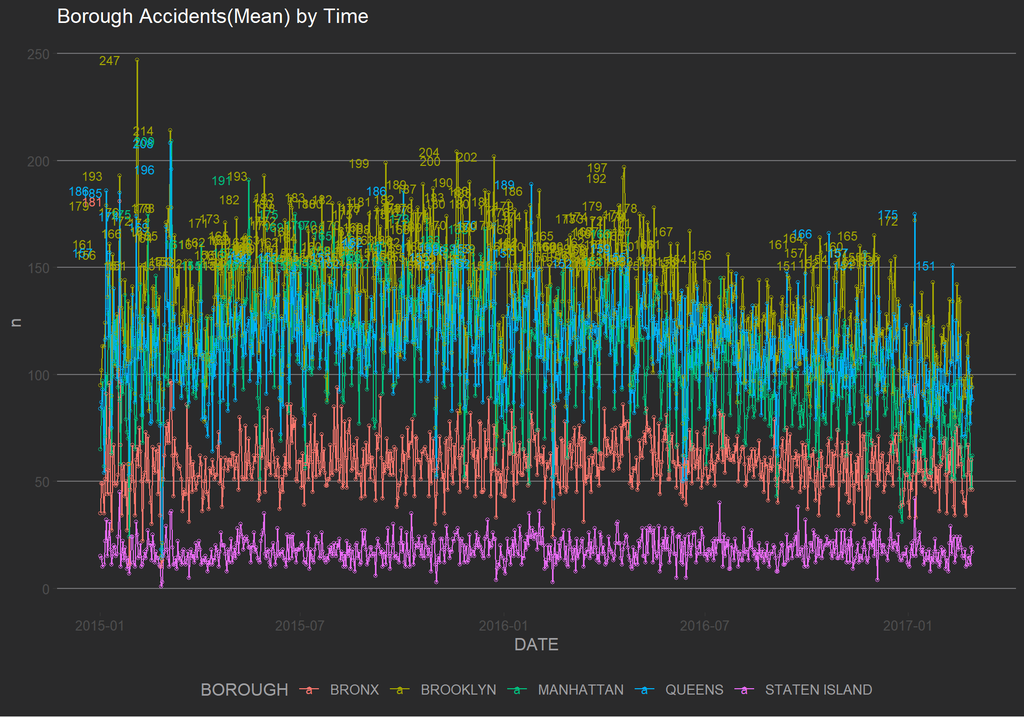

```r
bat <- col %>% filter(BOROUGH!="") %>% group_by(DATE,BOROUGH) %>% tally() %>% na.omit()
ggplot(data = bat, aes(x=DATE, y=n, colour=BOROUGH, group=BOROUGH)) + geom_line()+geom_point(size=1,shape=1)+theme_hc(style = "darkunica") + scale_fill_hc("darkunica") +ggtitle("Borough Accidents(Mean) by Time")+geom_text(aes(label=ifelse(n>150,n,"")), size=3,hjust=1.8)
```

The least # of accidents among all other boroughs happend Staten Island, but it has the lowest population.Number of accidents do increase with increase in population. We see that the boroughs with the largest number of accidents are Brooklyn, Manhattan and Queens which are also the most populated boroughs in NYC.

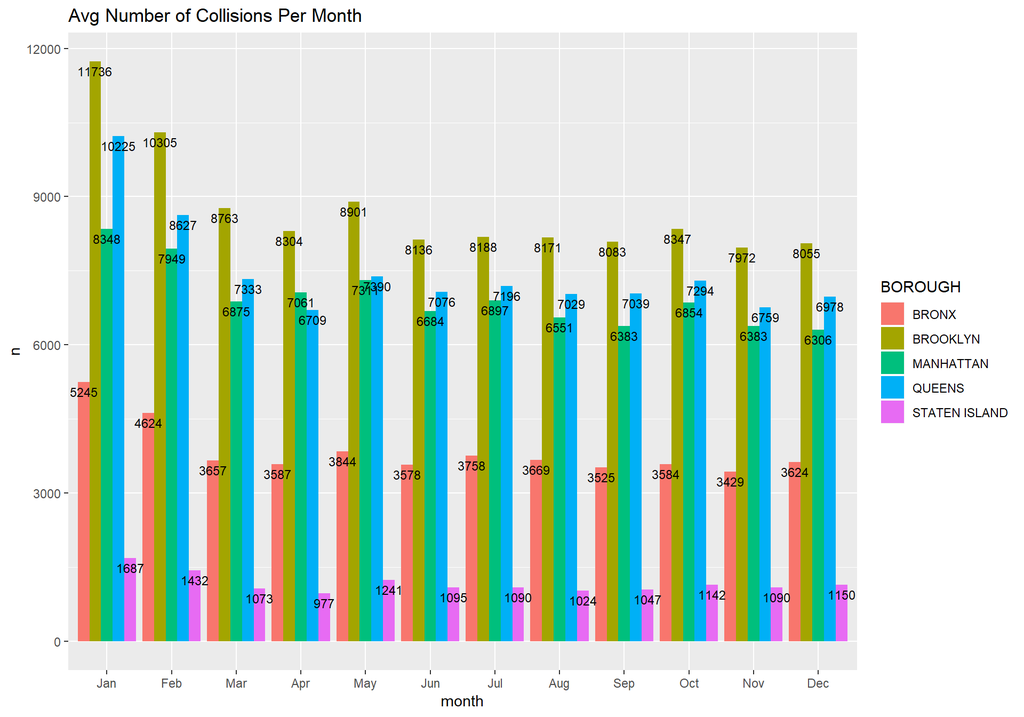

```r
col %>% filter(BOROUGH!="") %>% group_by(month,BOROUGH) %>% tally() %>% na.omit() %>% ggplot(aes(x=month, y=n, fill=BOROUGH)) + geom_bar(position="dodge",stat = "identity") + geom_text(aes(label=n), vjust=1.5, colour="black", position=position_dodge(.9), size=3) + ggtitle("Avg Number of Collisions Per Month")
```

The highest number of accidents took place in Brooklyn. Brooklyn also has the highest population amongst the Boroughs mentioned. The second largest Borough in terms of population is Queens. We see that the average number of accidents in Queens was the second largest for all the months except April.Queens has the second largest population in NYC. The lowest number of accidents was generated by Staten Island.It happens to have the lowest population as well.

*Do weekends have higher accidents than week days?*

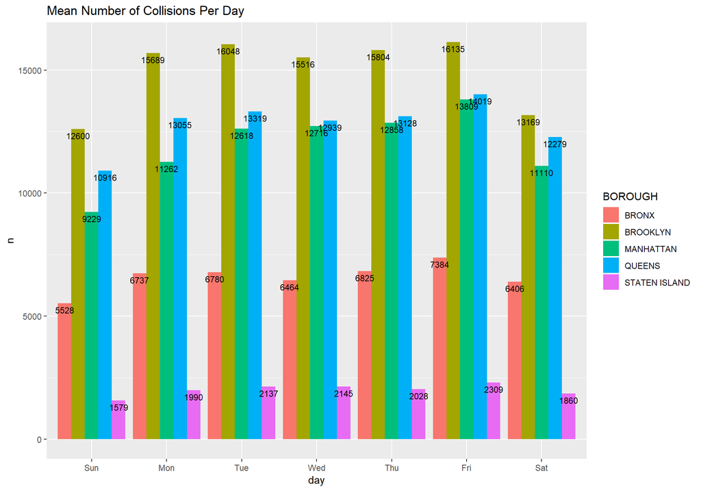

```r
col %>% group_by(BOROUGH,day)%>% tally() %>% filter(BOROUGH!="") %>% ggplot(aes(x=day, y=n, fill=BOROUGH)) +
geom_bar(position="dodge",stat = "identity")+geom_text(aes(label=n), vjust=1.5, colour="black",
position=position_dodge(.9), size=3)+ggtitle("Mean Number of Collisions Per Day")
```

**Reasons for accidents to take place** What are the most frequent causes of accidents to take place?

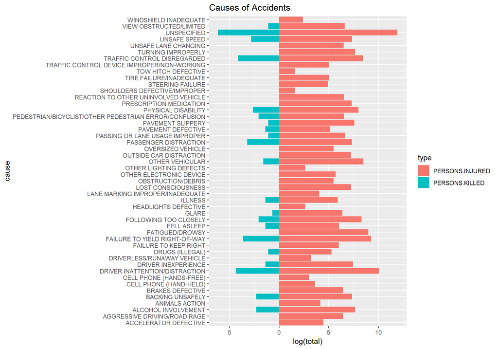

```r
temp <- col %>% select(PERSONS.KILLED,PERSONS.INJURED,VEHICLE.1.FACTOR,VEHICLE.2.FACTOR,VEHICLE.3.FACTOR,VEHICLE.4.FACTOR,VEHICLE.5.FACTOR) %>% gather(type,value,1:2) %>% gather(vehicle_type,cause,1:5) %>% filter(value!=0,cause!="",cause!="Unspecified")

temp_1 <- temp %>% select(-vehicle_type) %>% group_by(type,cause) %>% summarise( total = sum(value,na.rm=T))

ggplot(data = temp_1, aes(x = cause, y = log(total), fill = type)) +
  geom_bar(data = subset(temp_1, type=="PERSONS.INJURED"),
           stat = "identity") +
  geom_bar(data = subset(temp_1, type=="PERSONS.KILLED"),
           stat = "identity",
           position = "identity",
           mapping = aes(y = -log(total))) +
  scale_y_continuous(labels = abs) +
  coord_flip()+ggtitle('Causes of Accidents')
```

**Times Series Animation**

[figure not shown]

## Injuries Due to Accidents

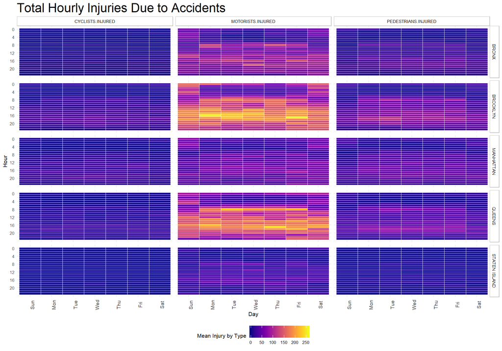

```r
temp <- col %>% select(BOROUGH,DATE,MOTORISTS.INJURED,CYCLISTS.INJURED,PEDESTRIANS.INJURED,day,hour) %>% gather(type,value,3:5) %>% group_by(BOROUGH,type,day,hour) %>% summarise(n=sum(value,na.rm=T))

temp <- filter(temp,BOROUGH!="")

p <-ggplot(temp,aes(day,hour,fill=(n)))+
  geom_tile(color= "white",size=0.1) +
  scale_fill_viridis(name="Mean Injury by Type",option ="C")
p <-p + facet_grid(BOROUGH~type)
p <-p + scale_y_continuous(trans = "reverse", breaks = c(0,4,8,12,16,20))
#p <-p + scale_x_continuous(breaks =c(1,10,20,31))
p <-p + theme_minimal(base_size = 8)
p <-p + labs(title= paste("Total Hourly Injuries Due to Accidents"), x="Day", y="Hour")
p <-p + theme(legend.position = "bottom")+
  theme(plot.title=element_text(size = 14))+
  theme(axis.text.y=element_text(size=6)) +
  theme(strip.background = element_rect(colour="gray"))+
  theme(plot.title=element_text(hjust=0))+
  theme(axis.ticks=element_blank())+
  theme(axis.text=element_text(size=7))+
  theme(legend.title=element_text(size=8))+
  theme(legend.text=element_text(size=6))+
  theme(plot.title=element_text(size=18),axis.text.x = element_text(angle=90, vjust=1))
(p)
```

### Time Series Plots

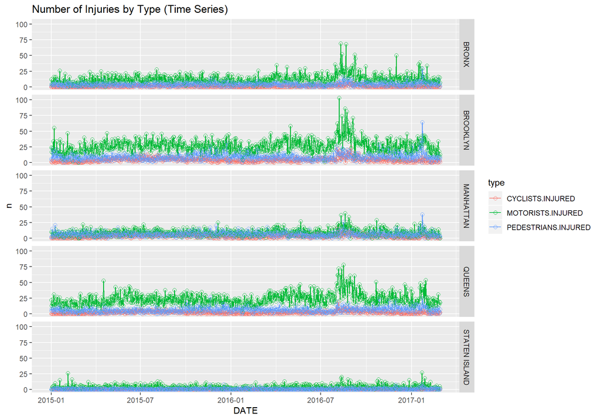

```r
p <- col %>% select(BOROUGH,DATE,MOTORISTS.INJURED,CYCLISTS.INJURED,PEDESTRIANS.INJURED) %>% gather(type,value,3:5) %>% group_by(BOROUGH,type,DATE) %>% summarise(n=sum(value,na.rm=T)) %>% filter(BOROUGH!="") %>%
  ggplot(aes(x=DATE,y=n,colour=type)) + geom_line() + geom_point(size=2,shape=1)+
facet_grid(BOROUGH ~ .)+ggtitle("Number of Injuries by Type (Time Series)")

(p)
```

**Most injuries involved motorists**

## Deaths

### Deaths by Hour and Day

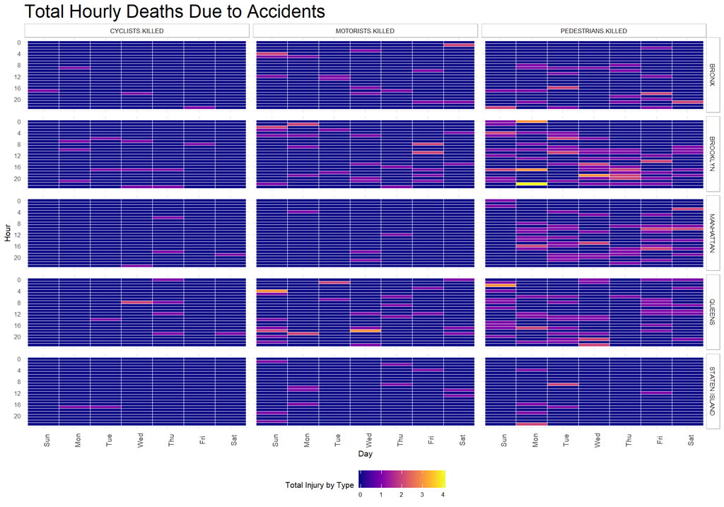

```r
temp <- col %>% select(BOROUGH,DATE,MOTORISTS.KILLED,CYCLISTS.KILLED,PEDESTRIANS.KILLED,day,hour) %>% gather(type,value,3:5) %>% group_by(BOROUGH,type,day,hour) %>% summarise(n=sum(value,na.rm=T))

temp <- filter(temp,BOROUGH!="")

p <-ggplot(temp,aes(day,hour,fill=(n)))+
  geom_tile(color= "white",size=0.1) +
  scale_fill_viridis(name="Total Injury by Type",option ="C")
p <-p + facet_grid(BOROUGH~type)
p <-p + scale_y_continuous(trans = "reverse", breaks = c(0,4,8,12,16,20))
#p <-p + scale_x_continuous(breaks =c(1,10,20,31))
p <-p + theme_minimal(base_size = 8)
p <-p + labs(title= paste("Total Hourly Deaths Due to Accidents"), x="Day", y="Hour")
p <-p + theme(legend.position = "bottom")+
  theme(plot.title=element_text(size = 14))+
  theme(axis.text.y=element_text(size=6)) +
  theme(strip.background = element_rect(colour="gray"))+
  theme(plot.title=element_text(hjust=0))+
  theme(axis.ticks=element_blank())+
  theme(axis.text=element_text(size=7))+
  theme(legend.title=element_text(size=8))+
  theme(legend.text=element_text(size=6))+
  theme(plot.title=element_text(size=18),axis.text.x = element_text(angle=90, vjust=1))
(p)
```

### Time Series Plots

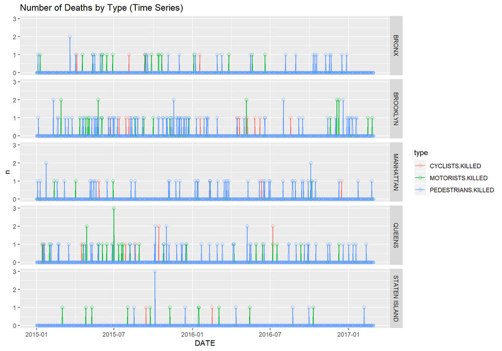

```r
p <- col %>% select(BOROUGH,DATE,MOTORISTS.KILLED,CYCLISTS.KILLED,PEDESTRIANS.KILLED) %>% gather(type,value,3:5) %>% group_by(BOROUGH,type,DATE) %>% summarise(n=sum(value,na.rm=T)) %>% filter(BOROUGH!="") %>%
  ggplot(aes(x=DATE,y=n,colour=type)) + geom_line() + geom_point(size=2,shape=1)+
facet_grid(BOROUGH ~ .)+ggtitle("Number of Deaths by Type (Time Series)")
p
```

## Location Wise Plot(Injuries)

[figure not shown]

From Google Map